# PMM/MMC Mandibular Analysis

Christopher A Schmitt

11/22/2016

This is a coding file outlining our analyses for our PNAS paper:

**Hlusko LJ, Schmitt CA, Monson T, Brasil M and Mahaney MC. 2016. The integration of quantitative genetics, paleontology, and neontology reveals genetic underpinnings of primate dental evolution. Proc Nat Acad Sci 113(33): 9262-9267.**

(insofar as they were conducted in R; other analyses or data processes were done using Excel, SOLAR, and Photoshop). This document won’t have EVERY analyses we ran, but will have representative examples, and all code for figures/results presented in the main body of the paper.

Let’s get started by loading the packages we’ll be using for data organization, analyses, and plots:

```r
library(ggplot2)
library(dplyr)
library(ape)
library(MCMCglmm)
library(geiger)
library(phytools)
```

Also, for this code to work, please place all datafiles in your working directory. You can define your working directory by navigating to it under the ‘Session’ tab if using RStudio, or by using the ‘*setwd()*’ prompt (please enter manually, since the working directory will depend on your computer).

To begin, we’ll take a look at some of the baseline plots that were used to generate our figures in the paper.

For these plots, we’ll be using the datafile ‘**CatarrhineMandibularData_22NOV16.csv**’. Note that this file has novel *Homo sapiens* datapoints, and so may appear different from the figures in the paper. Let’s bring in that dataset now, and format for use with ‘dplyr’:

```r
teeth<-read.csv(file("CatarrhineMandibularData_22NOV16.csv"),header=T,sep=",")
teeth<-tbl_df(teeth)
```

Let’s start with a graph showing PMM/MMC for just the extant Cercopithecoids. Before starting, let’s use ‘dplyr’ to isolate the Cercopothecoid samples for use in the graph:

```r
teeth.cerc<-
  teeth %>%
  filter(Subfamily=='Cercopithecoid') %>%
  select(id,phylo,MMC,PMM,plot_text) %>%
  droplevels() %>%
  na.omit()
```

Now that the Cercopithecoids are isolated, we can graph just the extant taxa. Note that for this graph, given how many samples need aesthetics, we opted to exclude fossil samples in the graphical procedure rather than in the data isolation procedure (above), in order to avoid rewriting the graphics code from scratch.

Here, you can see the basic Cercopithecoid dataset from Figure 1B:

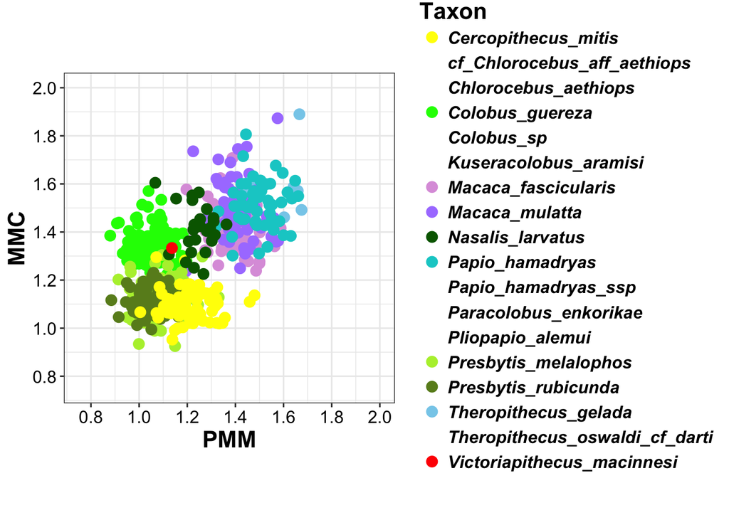

```r
g1<-ggplot(data=teeth.cerc,aes(x=PMM,y=MMC,colour=phylo,shape=phylo,label=phylo,alpha=phylo,size=phylo))+coord_fixed(ratio=1)+geom_point()+theme_bw()+scale_x_continuous(limits=c(0.75,2.0),breaks=c(0.8,1.0,1.2,1.4,1.6,1.8,2.0))+scale_y_continuous(limits=c(0.75,2.0),breaks=c(0.8,1.0,1.2,1.4,1.6,1.8,2.0))+theme(axis.text=element_text(size="12", color="black", family="Arial"),axis.title=element_text(face="bold", size="16", color="black", family="Arial"),legend.title=element_text(face="bold", size="16", color="black", family="Arial"),legend.text=element_text(face="bold.italic", size="12", color="black", family="Arial"))
g2<-g1+guides(colour=guide_legend(ncol=1),shape=guide_legend(ncol=1))+labs(x="PMM",y="MMC")
g3<-g2+scale_shape_manual(name="Taxon",values=c(16,NA,16,16,NA,NA,16,16,16,16,NA,NA,NA,16,16,16,NA,16),breaks=c("Cercopithecus_mitis","cf_Chlorocebus_aff_aethiops","Chlorocebus_aethiops","Colobus_guereza","Colobus_sp","Kuseracolobus_aramisi","Macaca_fascicularis","Macaca_mulatta","Nasalis_larvatus","Papio_hamadryas","Papio_hamadryas_ssp","Paracolobus_enkorikae","Pliopapio_alemui","Presbytis_melalophos","Presbytis_rubicunda","Theropithecus_gelada","Theropithecus_oswaldi_cf_darti","Victoriapithecus_macinnesi"))
g4<-g3+scale_colour_manual(  name="Taxon",values=c("yellow","darkgoldenrod2","goldenrod1","green","darkgreen","green4","plum","mediumpurple1","darkgreen","cyan3","cyan3","green4","cyan3","olivedrab2","olivedrab4","skyblue","skyblue","red"),
breaks=c("Cercopithecus_mitis","cf_Chlorocebus_aff_aethiops","Chlorocebus_aethiops","Colobus_guereza","Colobus_sp","Kuseracolobus_aramisi","Macaca_fascicularis","Macaca_mulatta","Nasalis_larvatus","Papio_hamadryas","Papio_hamadryas_ssp","Paracolobus_enkorikae","Pliopapio_alemui","Presbytis_melalophos","Presbytis_rubicunda","Theropithecus_gelada","Theropithecus_oswaldi_cf_darti","Victoriapithecus_macinnesi"))
g5<-g4+scale_size_manual(name="Taxon",values=c(3.5,5,3.5,3.5,5,5,3.5,3.5,3.5,3.5,5,5,5,3.5,3.5,3.5,5,3.5),
breaks=c("Cercopithecus_mitis","cf_Chlorocebus_aff_aethiops","Chlorocebus_aethiops","Colobus_guereza","Colobus_sp","Kuseracolobus_aramisi","Macaca_fascicularis","Macaca_mulatta","Nasalis_larvatus","Papio_hamadryas","Papio_hamadryas_ssp","Paracolobus_enkorikae","Pliopapio_alemui","Presbytis_melalophos","Presbytis_rubicunda","Theropithecus_gelada","Theropithecus_oswaldi_cf_darti","Victoriapithecus_macinnesi"))
g6<-g5+scale_alpha_manual(name="Taxon",values=c(1,0,0,1,0,0,1,1,1,1,0,0,0,1,1,1,0,1),
breaks=c("Cercopithecus_mitis","cf_Chlorocebus_aff_aethiops","Chlorocebus_aethiops","Colobus_guereza","Colobus_sp","Kuseracolobus_aramisi","Macaca_fascicularis","Macaca_mulatta","Nasalis_larvatus","Papio_hamadryas","Papio_hamadryas_ssp","Paracolobus_enkorikae","Pliopapio_alemui","Presbytis_melalophos","Presbytis_rubicunda","Theropithecus_gelada","Theropithecus_oswaldi_cf_darti","Victoriapithecus_macinnesi"))
print(g6)
```

And to print this out in the appropriate size and resolution:

```r
ggsave(filename="MMCPMM_CERCextant.tiff",height=4,width=15,dpi=600)
```

Now, to just do the fossil Cercopithecoids, as in Figure 1C:

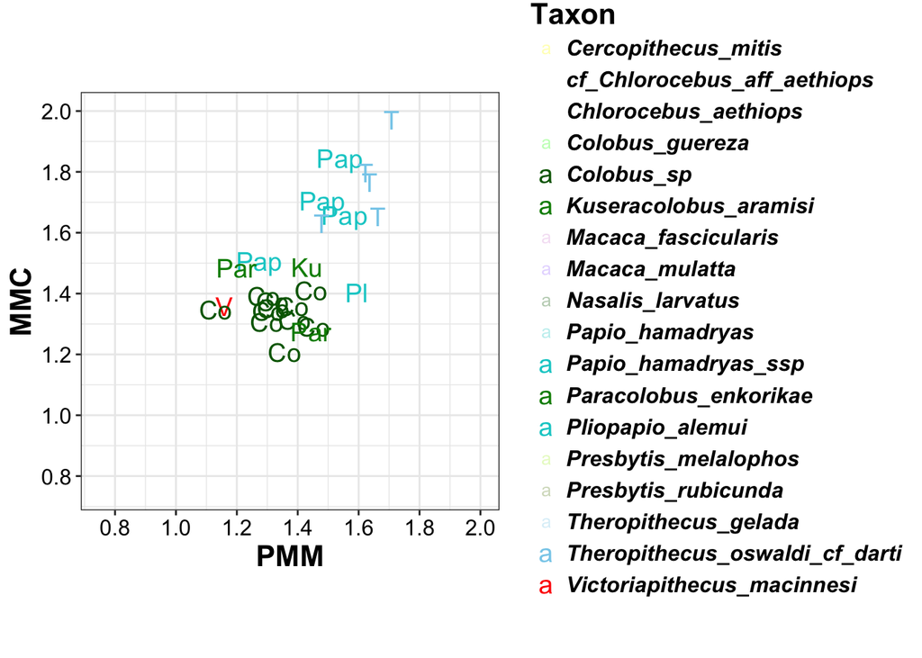

```r
g1<-ggplot(data=teeth.cerc,aes(x=PMM,y=MMC,colour=phylo,shape=phylo,label=phylo,alpha=phylo,size=phylo))+coord_fixed(ratio=1)+geom_point()+theme_bw()+geom_text(aes(label=plot_text,vjust=0.1,hjust=0.1))+scale_x_continuous(limits=c(0.75,2.0),breaks=c(0.8,1.0,1.2,1.4,1.6,1.8,2.0))+scale_y_continuous(limits=c(0.75,2.0),breaks=c(0.8,1.0,1.2,1.4,1.6,1.8,2.0))+theme(axis.text=element_text(size="12", color="black", family="Arial"),axis.title=element_text(face="bold", size="16", color="black", family="Arial"),legend.title=element_text(face="bold", size="16", color="black", family="Arial"),legend.text=element_text(face="bold.italic", size="12", color="black", family="Arial"))
g2<-g1+guides(colour=guide_legend(ncol=1),shape=guide_legend(ncol=1))+labs(x="PMM",y="MMC")
g3<-g2+scale_shape_manual(name="Taxon",values=c(NA,NA,NA,NA,NA,NA,NA,NA,NA,NA,NA,NA,NA,NA,NA,NA,NA,NA),breaks=c("Cercopithecus_mitis","cf_Chlorocebus_aff_aethiops","Chlorocebus_aethiops","Colobus_guereza","Colobus_sp","Kuseracolobus_aramisi","Macaca_fascicularis","Macaca_mulatta","Nasalis_larvatus","Papio_hamadryas","Papio_hamadryas_ssp","Paracolobus_enkorikae","Pliopapio_alemui","Presbytis_melalophos","Presbytis_rubicunda","Theropithecus_gelada","Theropithecus_oswaldi_cf_darti","Victoriapithecus_macinnesi"))
g4<-g3+scale_colour_manual(  name="Taxon",values=c("yellow","darkgoldenrod2","goldenrod1","green","darkgreen","green4","plum","mediumpurple1","darkgreen","cyan3","cyan3","green4","cyan3","olivedrab2","olivedrab4","skyblue","skyblue","red"),
breaks=c("Cercopithecus_mitis","cf_Chlorocebus_aff_aethiops","Chlorocebus_aethiops","Colobus_guereza","Colobus_sp","Kuseracolobus_aramisi","Macaca_fascicularis","Macaca_mulatta","Nasalis_larvatus","Papio_hamadryas","Papio_hamadryas_ssp","Paracolobus_enkorikae","Pliopapio_alemui","Presbytis_melalophos","Presbytis_rubicunda","Theropithecus_gelada","Theropithecus_oswaldi_cf_darti","Victoriapithecus_macinnesi"))
g5<-g4+scale_size_manual(name="Taxon",values=c(3.5,5,3.5,3.5,5,5,3.5,3.5,3.5,3.5,5,5,5,3.5,3.5,3.5,5,5),
breaks=c("Cercopithecus_mitis","cf_Chlorocebus_aff_aethiops","Chlorocebus_aethiops","Colobus_guereza","Colobus_sp","Kuseracolobus_aramisi","Macaca_fascicularis","Macaca_mulatta","Nasalis_larvatus","Papio_hamadryas","Papio_hamadryas_ssp","Paracolobus_enkorikae","Pliopapio_alemui","Presbytis_melalophos","Presbytis_rubicunda","Theropithecus_gelada","Theropithecus_oswaldi_cf_darti","Victoriapithecus_macinnesi"))
g6<-g5+scale_alpha_manual(name="Taxon",values=c(0.3,0,0,0.3,1,1,0.3,0.3,0.3,0.3,1,1,1,0.3,0.3,0.3,1,1),
breaks=c("Cercopithecus_mitis","cf_Chlorocebus_aff_aethiops","Chlorocebus_aethiops","Colobus_guereza","Colobus_sp","Kuseracolobus_aramisi","Macaca_fascicularis","Macaca_mulatta","Nasalis_larvatus","Papio_hamadryas","Papio_hamadryas_ssp","Paracolobus_enkorikae","Pliopapio_alemui","Presbytis_melalophos","Presbytis_rubicunda","Theropithecus_gelada","Theropithecus_oswaldi_cf_darti","Victoriapithecus_macinnesi"))
print(g6)
```

```r
ggsave(filename="MMCPMM_CERCfossil.tiff",height=4,width=15,dpi=600)
```

And the P4 by M1 area graph for extant Cercopithecoids in Figure 1A:

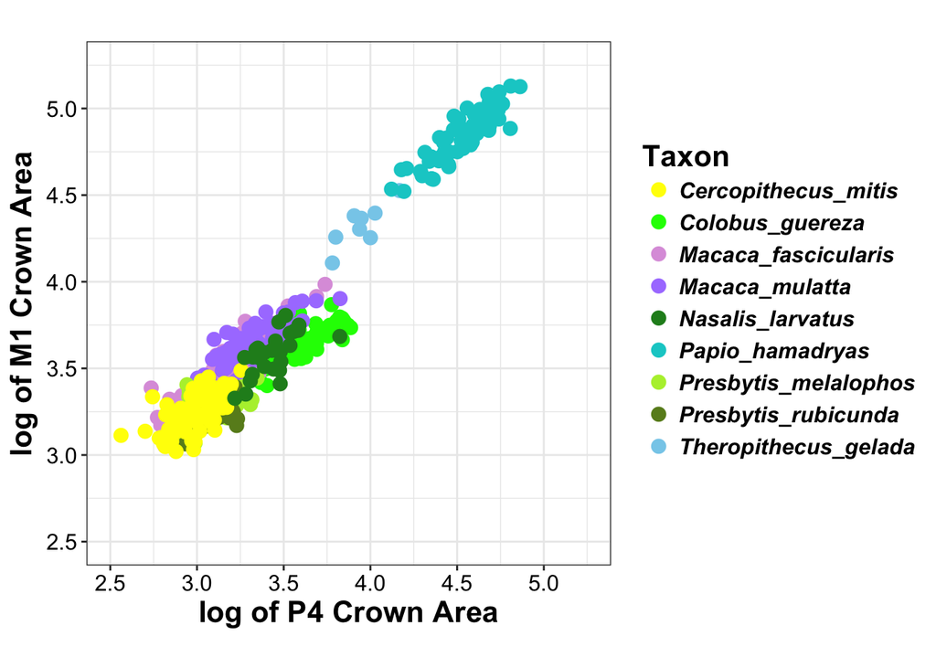

```r
teeth.area<-
  teeth %>%
  filter(Subfamily=='Cercopithecoid') %>%
  select(id,phylo,LP4_area,LM1_area,plot_text) %>%
  droplevels() %>%
  na.omit()

g1<-ggplot(data=teeth.area,aes(x=log(LP4_area),y=log(LM1_area),colour=phylo,shape=phylo,label=phylo,alpha=phylo,size=phylo))+coord_fixed(ratio=1)+geom_point()+theme_bw()+scale_x_continuous(limits=c(2.5,5.25),breaks=c(2.5,3,3.5,4,4.5,5))+scale_y_continuous(limits=c(2.5,5.25),breaks=c(2.5,3,3.5,4,4.5,5))+theme(axis.text=element_text(size="12", color="black", family="Arial"),axis.title=element_text(face="bold", size="16", color="black", family="Arial"),legend.title=element_text(face="bold", size="16", color="black", family="Arial"),legend.text=element_text(face="bold.italic", size="12", color="black", family="Arial"))
g2<-g1+guides(colour=guide_legend(ncol=1),shape=guide_legend(ncol=1))+labs(x="log of P4 Crown Area",y="log of M1 Crown Area")
g3<-g2+scale_shape_manual(name="Taxon",values=c(16,16,16,16,16,16,16,16,16),breaks=c("Cercopithecus_mitis","Colobus_guereza","Macaca_fascicularis","Macaca_mulatta","Nasalis_larvatus","Papio_hamadryas","Presbytis_melalophos","Presbytis_rubicunda","Theropithecus_gelada"))
g4<-g3+scale_colour_manual(  name="Taxon",values=c("yellow","green","plum","mediumpurple1","forestgreen","cyan3","olivedrab2","olivedrab4","skyblue"), breaks=c("Cercopithecus_mitis","Colobus_guereza","Macaca_fascicularis","Macaca_mulatta","Nasalis_larvatus","Papio_hamadryas","Presbytis_melalophos","Presbytis_rubicunda","Theropithecus_gelada"))
g5<-g4+scale_size_manual(name="Taxon",values=c(3.5,3.5,3.5,3.5,3.5,3.5,3.5,3.5,3.5), breaks=c("Cercopithecus_mitis","Colobus_guereza","Macaca_fascicularis","Macaca_mulatta","Nasalis_larvatus","Papio_hamadryas","Presbytis_melalophos","Presbytis_rubicunda","Theropithecus_gelada"))
g6<-g5+scale_alpha_manual(name="Taxon",values=c(1,1,1,1,1,1,1,1,1), breaks=c("Cercopithecus_mitis","Colobus_guereza","Macaca_fascicularis","Macaca_mulatta","Nasalis_larvatus","Papio_hamadryas","Presbytis_melalophos","Presbytis_rubicunda","Theropithecus_gelada"))
print(g6)
```

```r
ggsave(filename="P4M1area_CERCextant.tiff",height=4,width=15,dpi=600)
```

Now, we can also do this for the hominoids:

```r
teeth.hom<-
  teeth %>%
  filter(Subfamily=='Hominoid') %>%
  select(id,phylo,MMC,PMM,plot_text) %>%
  droplevels() %>%
  na.omit()
```

Here we have the extants only (Figure 2A, legend excluded):

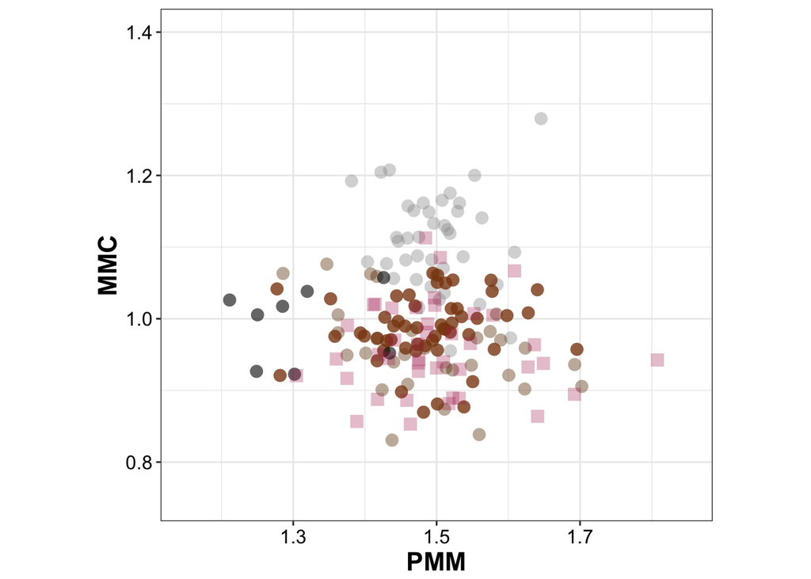

```r
g1<-ggplot(data=teeth.hom,aes(x=PMM,y=MMC,colour=phylo,shape=phylo,label=phylo,alpha=phylo,size=phylo))+coord_fixed(ratio=1,xlim=c(1.15,1.85),ylim=c(0.75,1.4))+geom_point(position = position_jitter(width=0.01,height=0.01))+theme_bw()+geom_text(aes(label=plot_text,vjust=0.1,hjust=0.1),fontface="bold")+theme(axis.text=element_text(size="12", color="black", family="Arial"),axis.title=element_text(face="bold", size="16", color="black", family="Arial"),legend.title=element_text(face="bold", size="16", color="black", family="Arial"),legend.text=element_text(face="bold.italic", size="12", color="black", family="Arial"))
g2<-g1+guides(colour=guide_legend(ncol=2),shape=guide_legend(ncol=2))+labs(x="PMM",y="MMC")
g3<-g2+scale_shape_manual(name="Taxon",values=c(NA,NA,NA,NA,NA,NA,NA,NA,NA,16,NA,6,17,16,1,15,15,0,2,NA,NA,NA,NA,NA,16,16,16,NA,NA,NA,NA,NA,NA),breaks=c("Afropithecus_turkanensis","Ankarapithecus_meteai","Ardipithecus_ramidus","Australopithecus_afarensis","Australopithecus_africanus","Australopithecus_anamensis","Australopithecus_boisei","Australopithecus_garhi","Australopithecus_robustus","Gorilla_gorilla","Griphopithecus_alpani","Homo_antecessor","Homo_erectus","Homo_heidelbergensis","Homo_neanderthalensis","Homo_sapiens","Homo_sapiens_archaic","Homo_sp._(Dmanisi)","Homo_sp._(Sima)","Kenyapithecus_africanus","Khoratpithecus_piriyai","Limnopithecus_legetet","Micropithecus_clarki","Ouranopithecus_macedoniensis","Pan_paniscus","Pan_troglodytes","Pongo_pygmaeus","Proconsul_africanus","Proconsul_heseloni","Proconsul_major","Proconsul_nyanzae","Rangwapithecus_gordoni","Sivapithecus_indicus"))
g4<-g3+scale_colour_manual(  name="Taxon",values=c("darkslategray","grey10","tomato4","tomato3","tomato3","tomato3","tomato3","tomato3","tomato3","grey60","darkslategray","maroon","maroon","maroon","maroon","maroon","maroon","maroon","maroon","darkslategray","grey10","darkslategray","darkslategray","grey10","#663300","chocolate4","black","darkslategray4","darkslategray4","darkslategray4","darkslategray4","darkslategray4","grey10"),
breaks=c("Afropithecus_turkanensis","Ankarapithecus_meteai","Ardipithecus_ramidus","Australopithecus_afarensis","Australopithecus_africanus","Australopithecus_anamensis","Australopithecus_boisei","Australopithecus_garhi","Australopithecus_robustus","Gorilla_gorilla","Griphopithecus_alpani","Homo_antecessor","Homo_erectus","Homo_heidelbergensis","Homo_neanderthalensis","Homo_sapiens","Homo_sapiens_archaic","Homo_sp._(Dmanisi)","Homo_sp._(Sima)","Kenyapithecus_africanus","Khoratpithecus_piriyai","Limnopithecus_legetet","Micropithecus_clarki","Ouranopithecus_macedoniensis","Pan_paniscus","Pan_troglodytes","Pongo_pygmaeus","Proconsul_africanus","Proconsul_heseloni","Proconsul_major","Proconsul_nyanzae","Rangwapithecus_gordoni","Sivapithecus_indicus"))
g5<-g4+scale_size_manual(name="Taxon",values=c(3.1,3.1,3.1,3.1,3.5,3.1,3.1,3.1,3.1,3.5,3.1,3.5,3.5,3.5,3.5,3.5,3.5,3.5,3.5,3.5,3.1,3.1,3.1,3.1,3.5,3.5,3.5,3.1,3.1,3.1,3.1,3.1,3.1,3.1),
breaks=c("Afropithecus_turkanensis","Ankarapithecus_meteai","Ardipithecus_ramidus","Australopithecus_afarensis","Australopithecus_africanus","Australopithecus_anamensis","Australopithecus_boisei","Australopithecus_garhi","Australopithecus_robustus","Gorilla_gorilla","Griphopithecus_alpani","Homo_antecessor","Homo_erectus","Homo_heidelbergensis","Homo_neanderthalensis","Homo_sapiens","Homo_sapiens_archaic","Homo_sp._(Dmanisi)","Homo_sp._(Sima)","Kenyapithecus_africanus","Khoratpithecus_piriyai","Limnopithecus_legetet","Micropithecus_clarki","Ouranopithecus_macedoniensis","Pan_paniscus","Pan_troglodytes","Pongo_pygmaeus","Proconsul_africanus","Proconsul_heseloni","Proconsul_major","Proconsul_nyanzae","Rangwapithecus_gordoni","Sivapithecus_indicus"))
g6<-g5+scale_alpha_manual(name="Taxon",values=c(0,0,0,0,0,0,0,0,0,0.4,0,0,0,0,0,0.3,0,0,0,0,0,0,0,0,0.4,0.8,0.6,0,0,0,0,0,0),
breaks=c("Afropithecus_turkanensis","Ankarapithecus_meteai","Ardipithecus_ramidus","Australopithecus_afarensis","Australopithecus_africanus","Australopithecus_anamensis","Australopithecus_boisei","Australopithecus_garhi","Australopithecus_robustus","Gorilla_gorilla","Griphopithecus_alpani","Homo_antecessor","Homo_erectus","Homo_heidelbergensis","Homo_neanderthalensis","Homo_sapiens","Homo_sapiens_archaic","Homo_sp._(Dmanisi)","Homo_sp._(Sima)","Kenyapithecus_africanus","Khoratpithecus_piriyai","Limnopithecus_legetet","Micropithecus_clarki","Ouranopithecus_macedoniensis","Pan_paniscus","Pan_troglodytes","Pongo_pygmaeus","Proconsul_africanus","Proconsul_heseloni","Proconsul_major","Proconsul_nyanzae","Rangwapithecus_gordoni","Sivapithecus_indicus"))
g7<-g6+theme(legend.position='None')
print(g7)
```

Now, the first thing you may notice with this figure is that the morphospace occupied by humans is not nearly so neatly separated from *Pan* as it was with the *Homo* sample originally used in our paper. In this case, it would appear that *Pan* and *Homo* aren’t well-differentiated at all.

Here’s the same graph, but with just fossil hominins (Figure 2B, legend excluded):

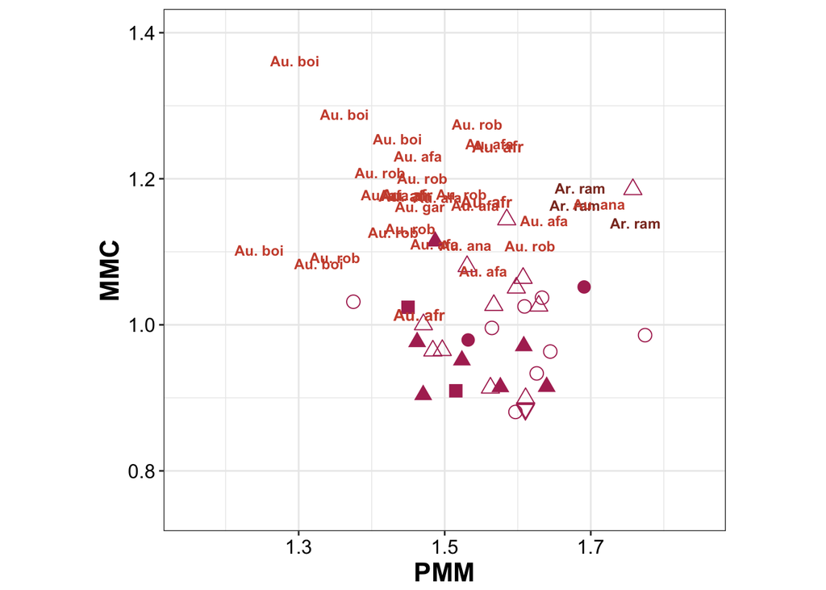

```r
g1<-ggplot(data=teeth.hom,aes(x=PMM,y=MMC,colour=phylo,shape=phylo,label=phylo,alpha=phylo,size=phylo))+coord_fixed(ratio=1,xlim=c(1.15,1.85),ylim=c(0.75,1.4))+geom_point(position = position_jitter(width=0.01,height=0.01))+theme_bw()+geom_text(aes(label=plot_text,vjust=0.1,hjust=0.1),fontface="bold")+theme(axis.text=element_text(size="12", color="black", family="Arial"),axis.title=element_text(face="bold", size="16", color="black", family="Arial"),legend.title=element_text(face="bold", size="16", color="black", family="Arial"),legend.text=element_text(face="bold.italic", size="12", color="black", family="Arial"))
g2<-g1+guides(colour=guide_legend(ncol=2),shape=guide_legend(ncol=2))+labs(x="PMM",y="MMC")
g3<-g2+scale_shape_manual(name="Taxon",values=c(0,0,NA,NA,NA,NA,NA,NA,NA,0,0,6,17,16,1,0,15,0,2,0,0,0,0,0,0,0,0,0,0,0,0,0,0),breaks=c("Afropithecus_turkanensis","Ankarapithecus_meteai","Ardipithecus_ramidus","Australopithecus_afarensis","Australopithecus_africanus","Australopithecus_anamensis","Australopithecus_boisei","Australopithecus_garhi","Australopithecus_robustus","Gorilla_gorilla","Griphopithecus_alpani","Homo_antecessor","Homo_erectus","Homo_heidelbergensis","Homo_neanderthalensis","Homo_sapiens","Homo_sapiens_archaic","Homo_sp._(Dmanisi)","Homo_sp._(Sima)","Kenyapithecus_africanus","Khoratpithecus_piriyai","Limnopithecus_legetet","Micropithecus_clarki","Ouranopithecus_macedoniensis","Pan_paniscus","Pan_troglodytes","Pongo_pygmaeus","Proconsul_africanus","Proconsul_heseloni","Proconsul_major","Proconsul_nyanzae","Rangwapithecus_gordoni","Sivapithecus_indicus"))
g4<-g3+scale_colour_manual(  name="Taxon",values=c("darkslategray","grey10","tomato4","tomato3","tomato3","tomato3","tomato3","tomato3","tomato3","grey60","darkslategray","maroon","maroon","maroon","maroon","maroon","maroon","maroon","maroon","darkslategray","grey10","darkslategray","darkslategray","grey10","#663300","chocolate4","black","darkslategray4","darkslategray4","darkslategray4","darkslategray4","darkslategray4","grey10"),
breaks=c("Afropithecus_turkanensis","Ankarapithecus_meteai","Ardipithecus_ramidus","Australopithecus_afarensis","Australopithecus_africanus","Australopithecus_anamensis","Australopithecus_boisei","Australopithecus_garhi","Australopithecus_robustus","Gorilla_gorilla","Griphopithecus_alpani","Homo_antecessor","Homo_erectus","Homo_heidelbergensis","Homo_neanderthalensis","Homo_sapiens","Homo_sapiens_archaic","Homo_sp._(Dmanisi)","Homo_sp._(Sima)","Kenyapithecus_africanus","Khoratpithecus_piriyai","Limnopithecus_legetet","Micropithecus_clarki","Ouranopithecus_macedoniensis","Pan_paniscus","Pan_troglodytes","Pongo_pygmaeus","Proconsul_africanus","Proconsul_heseloni","Proconsul_major","Proconsul_nyanzae","Rangwapithecus_gordoni","Sivapithecus_indicus"))
g5<-g4+scale_size_manual(name="Taxon",values=c(3.1,3.1,3.1,3.1,3.5,3.1,3.1,3.1,3.1,3.5,3.1,3.5,3.5,3.5,3.5,3.5,3.5,3.5,3.5,3.5,3.1,3.1,3.1,3.1,3.5,3.5,3.5,3.1,3.1,3.1,3.1,3.1,3.1,3.1),
breaks=c("Afropithecus_turkanensis","Ankarapithecus_meteai","Ardipithecus_ramidus","Australopithecus_afarensis","Australopithecus_africanus","Australopithecus_anamensis","Australopithecus_boisei","Australopithecus_garhi","Australopithecus_robustus","Gorilla_gorilla","Griphopithecus_alpani","Homo_antecessor","Homo_erectus","Homo_heidelbergensis","Homo_neanderthalensis","Homo_sapiens","Homo_sapiens_archaic","Homo_sp._(Dmanisi)","Homo_sp._(Sima)","Kenyapithecus_africanus","Khoratpithecus_piriyai","Limnopithecus_legetet","Micropithecus_clarki","Ouranopithecus_macedoniensis","Pan_paniscus","Pan_troglodytes","Pongo_pygmaeus","Proconsul_africanus","Proconsul_heseloni","Proconsul_major","Proconsul_nyanzae","Rangwapithecus_gordoni","Sivapithecus_indicus"))
g6<-g5+scale_alpha_manual(name="Taxon",values=c(0,0,1,1,1,1,1,1,1,0,0,1,1,1,1,0,1,0,1,0,0,0,0,0,0,0,0,0,0,0,0,0,0),
breaks=c("Afropithecus_turkanensis","Ankarapithecus_meteai","Ardipithecus_ramidus","Australopithecus_afarensis","Australopithecus_africanus","Australopithecus_anamensis","Australopithecus_boisei","Australopithecus_garhi","Australopithecus_robustus","Gorilla_gorilla","Griphopithecus_alpani","Homo_antecessor","Homo_erectus","Homo_heidelbergensis","Homo_neanderthalensis","Homo_sapiens","Homo_sapiens_archaic","Homo_sp._(Dmanisi)","Homo_sp._(Sima)","Kenyapithecus_africanus","Khoratpithecus_piriyai","Limnopithecus_legetet","Micropithecus_clarki","Ouranopithecus_macedoniensis","Pan_paniscus","Pan_troglodytes","Pongo_pygmaeus","Proconsul_africanus","Proconsul_heseloni","Proconsul_major","Proconsul_nyanzae","Rangwapithecus_gordoni","Sivapithecus_indicus"))
g7<-g6+theme(legend.position='None')
print(g7)
```

And only the hominoid fossils (Figure 2C; legend excluded):

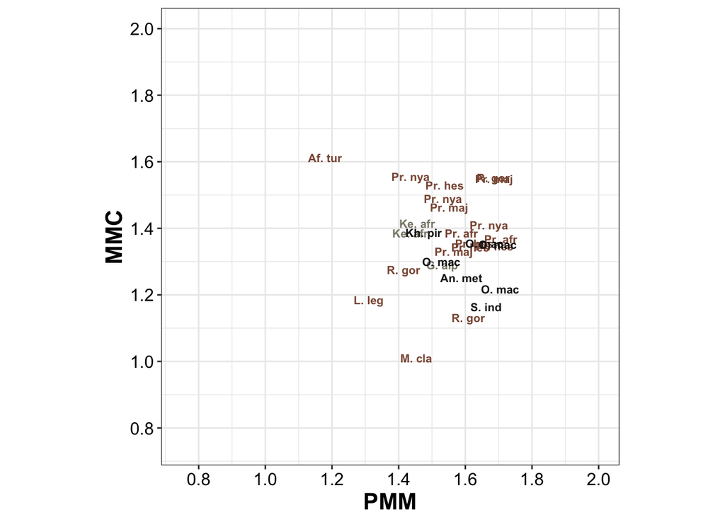

```r
teeth.prim<-
  teeth %>%
  filter(!(Subfamily=='NA')) %>%
  select(id,phylo,MMC,PMM,plot_text) %>%
  droplevels() %>%
  na.omit()

g1<-ggplot(data=teeth.prim,aes(x=PMM,y=MMC,colour=phylo,shape=phylo,label=phylo,alpha=phylo,size=phylo))+coord_fixed(ratio=1)+geom_point(position = position_jitter(width=0.01,height=0.01))+theme_bw()+geom_text(aes(label=plot_text,vjust=0.1,hjust=0.1),fontface="bold")+scale_x_continuous(limits=c(0.75,2.0),breaks=c(0.8,1.0,1.2,1.4,1.6,1.8,2.0))+scale_y_continuous(limits=c(0.75,2.0),breaks=c(0.8,1.0,1.2,1.4,1.6,1.8,2.0))+theme(axis.text=element_text(size="12", color="black", family="Arial"),axis.title=element_text(face="bold", size="16", color="black", family="Arial"),legend.title=element_text(face="bold", size="16", color="black", family="Arial"),legend.text=element_text(face="bold.italic", size="12", color="black", family="Arial"))
g2<-g1+guides(colour=guide_legend(ncol=3),shape=guide_legend(ncol=3))+labs(x="PMM",y="MMC")
g3<-g2+scale_shape_manual(name="Taxon",values=c(NA,NA,0,0,0,0,0,0,0,0,0,0,0,0,0,NA,0,0,0,0,0,0,0,0,NA,NA,0,NA,0,0,NA,0,NA,0,0,0,0,0,0,0,0,0,NA,NA,NA,NA,NA,NA,0,0,NA),breaks=c("Afropithecus_turkanensis","Ankarapithecus_meteai","Ardipithecus_ramidus","Australopithecus_afarensis","Australopithecus_africanus","Australopithecus_anamensis","Australopithecus_boisei","Australopithecus_garhi","Australopithecus_robustus","Cercopithecus_mitis","cf_Chlorocebus_aff_aethiops","Chlorocebus_aethiops","Colobus_guereza","Colobus_sp","Gorilla_gorilla","Griphopithecus_alpani","Homo_antecessor","Homo_erectus","Homo_heidelbergensis","Homo_neanderthalensis","Homo_sapiens","Homo_sapiens_archaic","Homo_sp._(Dmanisi)","Homo_sp._(Sima)","Kenyapithecus_africanus","Khoratpithecus_piriyai","Kuseracolobus_aramisi","Limnopithecus_legetet","Macaca_fascicularis","Macaca_mulatta","Micropithecus_clarki","Nasalis_larvatus","Ouranopithecus_macedoniensis","Pan_paniscus","Pan_troglodytes","Papio_hamadryas","Papio_hamadryas_ssp","Paracolobus_enkorikae","Pliopapio_alemui","Pongo_pygmaeus","Presbytis_melalophos","Presbytis_rubicunda","Proconsul_africanus","Proconsul_heseloni","Proconsul_major","Proconsul_nyanzae","Rangwapithecus_gordoni","Sivapithecus_indicus","Theropithecus_gelada","Theropithecus_oswaldi_cf_darti","Victoriapithecus_macinnesi"))
g4<-g3+scale_colour_manual(  name="Taxon",values=c("lightsalmon4","grey10","tomato4","tomato3","tomato3","tomato3","tomato3","tomato3","tomato3","yellow","darkgoldenrod2","goldenrod1","green","darkgreen","grey60","cornsilk4","maroon","maroon","maroon","maroon","maroon","maroon","maroon","maroon","cornsilk4","grey10","green4","lightsalmon4","plum","mediumpurple1","lightsalmon4","darkgreen","grey10","#663300","chocolate4","cyan3","cyan3","green4","cyan3","black","olivedrab2","olivedrab4","lightsalmon4","lightsalmon4","lightsalmon4","lightsalmon4","lightsalmon4","grey10","skyblue","skyblue","red"),
breaks=c("Afropithecus_turkanensis","Ankarapithecus_meteai","Ardipithecus_ramidus","Australopithecus_afarensis","Australopithecus_africanus","Australopithecus_anamensis","Australopithecus_boisei","Australopithecus_garhi","Australopithecus_robustus","Cercopithecus_mitis","cf_Chlorocebus_aff_aethiops","Chlorocebus_aethiops","Colobus_guereza","Colobus_sp","Gorilla_gorilla","Griphopithecus_alpani","Homo_antecessor","Homo_erectus","Homo_heidelbergensis","Homo_neanderthalensis","Homo_sapiens","Homo_sapiens_archaic","Homo_sp._(Dmanisi)","Homo_sp._(Sima)","Kenyapithecus_africanus","Khoratpithecus_piriyai","Kuseracolobus_aramisi","Limnopithecus_legetet","Macaca_fascicularis","Macaca_mulatta","Micropithecus_clarki","Nasalis_larvatus","Ouranopithecus_macedoniensis","Pan_paniscus","Pan_troglodytes","Papio_hamadryas","Papio_hamadryas_ssp","Paracolobus_enkorikae","Pliopapio_alemui","Pongo_pygmaeus","Presbytis_melalophos","Presbytis_rubicunda","Proconsul_africanus","Proconsul_heseloni","Proconsul_major","Proconsul_nyanzae","Rangwapithecus_gordoni","Sivapithecus_indicus","Theropithecus_gelada","Theropithecus_oswaldi_cf_darti","Victoriapithecus_macinnesi"))
g5<-g4+scale_size_manual(name="Taxon",values=c(2.8,2.8,2.8,2.8,2.8,2.8,2.8,2.8,2.8,2.8,2.8,3.5,3.5,2.8,3.5,2.8,3,3,3,3,3.5,3,3,3,2.8,2.8,2.8,2.8,3.5,3.5,2.8,3.5,2.8,3.5,3.5,3.5,2.8,2.8,2.8,3.5,3.5,3.5,2.8,2.8,2.8,2.8,2.8,2.8,3.5,2.8,2.8),
breaks=c("Afropithecus_turkanensis","Ankarapithecus_meteai","Ardipithecus_ramidus","Australopithecus_afarensis","Australopithecus_africanus","Australopithecus_anamensis","Australopithecus_boisei","Australopithecus_garhi","Australopithecus_robustus","Cercopithecus_mitis","cf_Chlorocebus_aff_aethiops","Chlorocebus_aethiops","Colobus_guereza","Colobus_sp","Gorilla_gorilla","Griphopithecus_alpani","Homo_antecessor","Homo_erectus","Homo_heidelbergensis","Homo_neanderthalensis","Homo_sapiens","Homo_sapiens_archaic","Homo_sp._(Dmanisi)","Homo_sp._(Sima)","Kenyapithecus_africanus","Khoratpithecus_piriyai","Kuseracolobus_aramisi","Limnopithecus_legetet","Macaca_fascicularis","Macaca_mulatta","Micropithecus_clarki","Nasalis_larvatus","Ouranopithecus_macedoniensis","Pan_paniscus","Pan_troglodytes","Papio_hamadryas","Papio_hamadryas_ssp","Paracolobus_enkorikae","Pliopapio_alemui","Pongo_pygmaeus","Presbytis_melalophos","Presbytis_rubicunda","Proconsul_africanus","Proconsul_heseloni","Proconsul_major","Proconsul_nyanzae","Rangwapithecus_gordoni","Sivapithecus_indicus","Theropithecus_gelada","Theropithecus_oswaldi_cf_darti","Victoriapithecus_macinnesi"))
g6<-g5+scale_alpha_manual(name="Taxon",values=c(1,1,0,0,0,0,0,0,0,0,0,0,0,0,0,1,0,0,0,0,0,0,0,0,1,1,0,1,0,0,1,0,1,0,0,0,0,0,0,0,0,0,1,1,1,1,1,1,0,0,0),
breaks=c("Afropithecus_turkanensis","Ankarapithecus_meteai","Ardipithecus_ramidus","Australopithecus_afarensis","Australopithecus_africanus","Australopithecus_anamensis","Australopithecus_boisei","Australopithecus_garhi","Australopithecus_robustus","Cercopithecus_mitis","cf_Chlorocebus_aff_aethiops","Chlorocebus_aethiops","Colobus_guereza","Colobus_sp","Gorilla_gorilla","Griphopithecus_alpani","Homo_antecessor","Homo_erectus","Homo_heidelbergensis","Homo_neanderthalensis","Homo_sapiens","Homo_sapiens_archaic","Homo_sp._(Dmanisi)","Homo_sp._(Sima)","Kenyapithecus_africanus","Khoratpithecus_piriyai","Kuseracolobus_aramisi","Limnopithecus_legetet","Macaca_fascicularis","Macaca_mulatta","Micropithecus_clarki","Nasalis_larvatus","Ouranopithecus_macedoniensis","Pan_paniscus","Pan_troglodytes","Papio_hamadryas","Papio_hamadryas_ssp","Paracolobus_enkorikae","Pliopapio_alemui","Pongo_pygmaeus","Presbytis_melalophos","Presbytis_rubicunda","Proconsul_africanus","Proconsul_heseloni","Proconsul_major","Proconsul_nyanzae","Rangwapithecus_gordoni","Sivapithecus_indicus","Theropithecus_gelada","Theropithecus_oswaldi_cf_darti","Victoriapithecus_macinnesi"))
g7<-g6+theme(legend.position='None')
print(g7)
```

OK, now we can look at the phylogenetic analyses we conducted. These will require a slightly different conformation of the database. Here, we’ll pull out all specimens except those that have branches on our planned tree:

```r
teeth<-
  teeth %>%
  filter(tree=="y")
```

And one dataframe each per phenotype. We’ll make two for separate analyses. The first two are for the Disparity Though Time analysis:

```r
teeth.dtt.pmm<-
  teeth %>%
  select(id,phylo,age,tree,PMM) %>%
  na.omit()
teeth.dtt.mmc<-
  teeth %>%
  select(id,phylo,age,tree,MMC) %>%
  na.omit()
```

The second two are for the PGLS analysis. In the initial analysis, we included Sex as a covariate, but given that the new *Homo sapiens* sample doesn’t have sex assignments, we will leave that out for this analysis, which may give slightly different results:

```r
teeth.pgls.pmm<-
  teeth %>%
  filter(age=='extant') %>%
  select(id,phylo,age,tree,DLM2AW,PMM) %>%
  na.omit() %>%
  droplevels()
teeth.pgls.mmc<-
  teeth %>%
  filter(age=='extant') %>%
  select(id,phylo,age,tree,DLM2AW,MMC) %>%
  na.omit() %>%
  droplevels()
```

OK, now we can actually pull in the phylogeny we’ll use. In our case, we used a file from 10kTrees, but the phylogeny was missing a few taxa that we had to add (we’ll go through that process, too).

First, we can upload the 10kTrees tile (called ‘consensusTree_10kTrees_Primates_Version3.nex’):

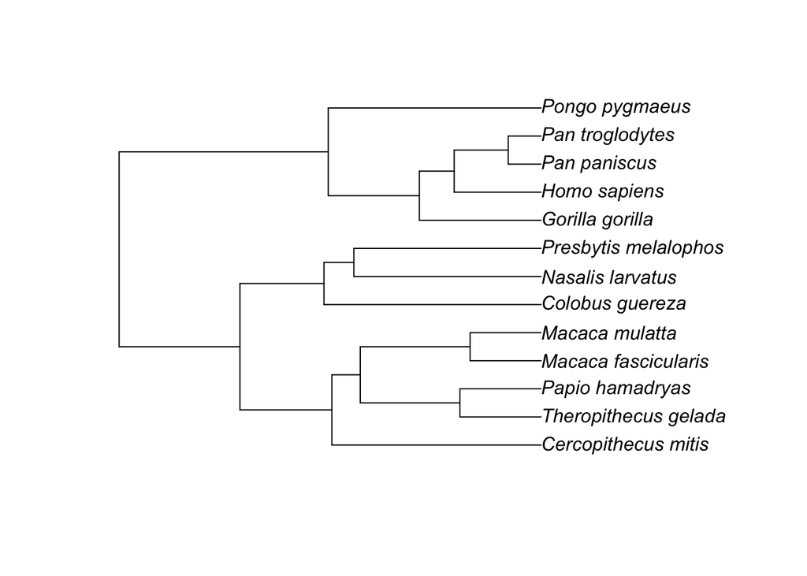

```r
treeBlock<-read.nexus("consensusTree_10kTrees_Primates_Version3_Final.nex")
plot.phylo(treeBlock)
```

That looks fine, but it’s missing *Presbytis rubicunda*, so we can use the following code to add it with just the name, sister taxon, and divergence date:

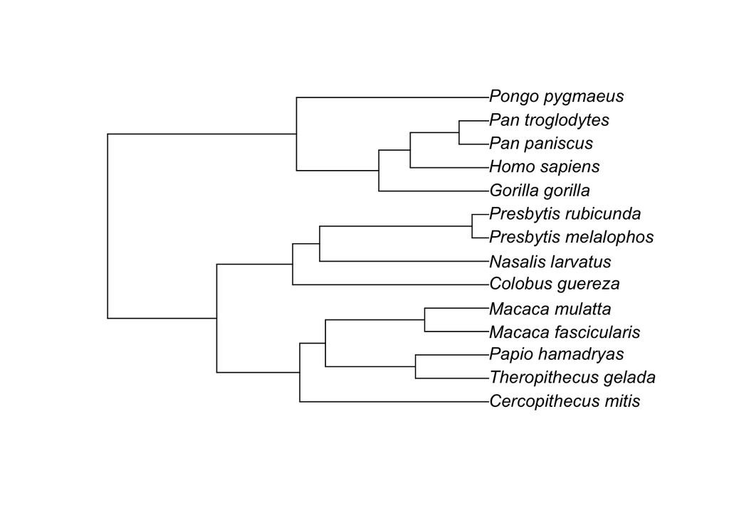

```r
speciesToBeInserted<-"Presbytis_rubicunda"
insertSpeciesNextTo<-"Presbytis_melalophos"
branchLengthSplitAgo<-1.31

    treeNewStr<-paste("(",speciesToBeInserted,":",branchLengthSplitAgo,");",sep="")
    treeNew<-read.tree(text=treeNewStr)
    # Read tree block (already read above as data object treeBlock:
  #treeBlock<-read.nexus(file.choose())
    treeBlockNew = list()
    #The following is an iterative loop that for each tree in the tree block:
    for (i in 1:length(treeBlock)) {
        #It will dentify the position (i.e., integer number) where insertNextT is located in the tree object:
pos = 0
for (j in 1: length(treeBlock$tip.label)) {
            if ( insertSpeciesNextTo ==
    treeBlock$tip.label[j]) {
                pos = j
}
        }
        if (pos == 0) {
            stop ("Error: Could not find species
    ",insertSpeciesNextTo, " in tree ",i,", exit\n")
}
        #Merge both trees and write tree to new list of trees:
        treeBlockNew= bind.tree(treeBlock,
    treeNew,where = pos, position = branchLengthSplitAgo)
}

write.nexus(treeBlockNew,file="treeBlockNew_Finalb.nex")

treeBlockNew<-read.nexus("treeBlockNew_Finalb.nex")
plot(treeBlockNew)
```

Ok, now we can run the phylogenetic least squares (PGLS) analysis with our new tree!

It seems like we should be able to just do this…

```r
phylo<-treeBlockNew
```

But unfortunately it doesn’t work that way… we have to use a .phy file for MCMCglmm. I had to make the .phy file by hand based on the .nex file output from the previous step (‘Catarrhines_finala.phy’):

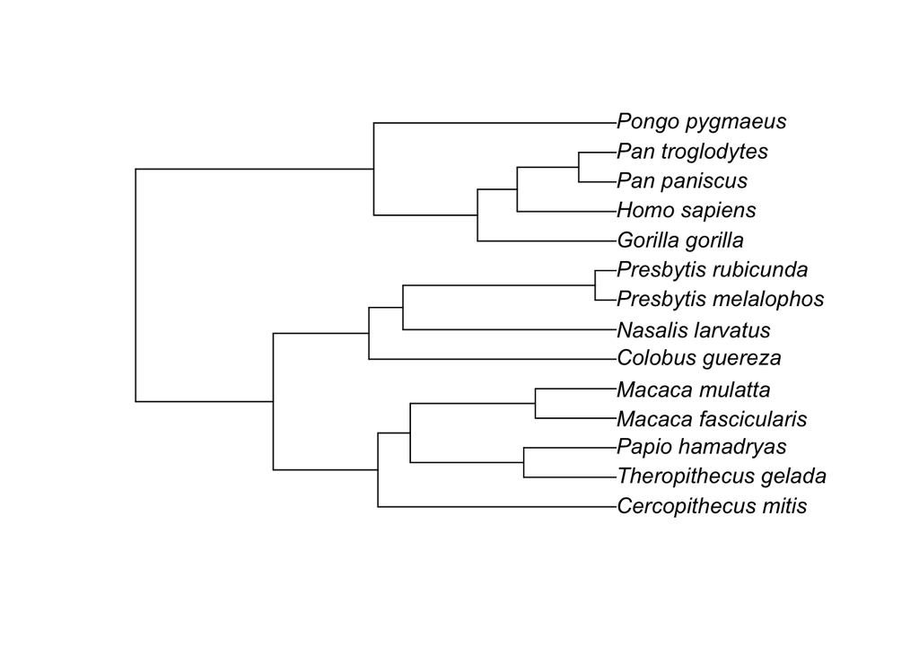

```r
phylo<-read.tree("Catarrhines_finala.phy")
plot(phylo)
```

Now we need to calculate the inverse of the Sigma matrix of phylogenetic correlation:

```r
inv.phylo<-inverseA(phylo,nodes="TIPS",scale=TRUE)
```

And then, since we are conducting this analysis using a Bayesian framework, we need to establish our priors. In our case, we used canonical uninformative priors (inverse-Gamma distribution):

```r
prior<-list(R=list(V=1,nu=0.02),
                G=list(G1=list(V=1,nu=0.02),
                          G2=list(V=1,nu=0.02)))
```

Also, for MCMCglmm to work, we need the level names of the taxa in the dataframe to be set as in the same order as in phylo. Let’s do that now:

```r
teeth.pgls.mmc$phylo<-factor(teeth.pgls.mmc$phylo,levels=c("Cercopithecus_mitis","Theropithecus_gelada","Papio_hamadryas","Macaca_fascicularis","Macaca_mulatta","Colobus_guereza","Nasalis_larvatus","Presbytis_melalophos","Presbytis_rubicunda","Gorilla_gorilla","Homo_sapiens","Pan_paniscus","Pan_troglodytes","Pongo_pygmaeus"))
```

And we need to make sure that the names in the dataframe are concordant with the names in our phylogenetic tree:

```r
blah1<-inv.phylo$node.names
blah2<-levels(teeth.pgls.mmc$phylo)
all(blah1 == blah2)
```

```
## [1] TRUE
```

We also need to convert our dplyr data table back into a dataframe for MCMCglmm to read it properly:

```r
pgls.mmc<-as.data.frame(teeth.pgls.mmc)
```

And now we can run our MMC model, incorporating phylogeny into it. In this case, we’re attempting to control for the effects of body size by including the anterior width of the second molar as a covariate in the models.

```r
model.phylo.mmc<-MCMCglmm(MMC~1,random=~DLM2AW+phylo,family="gaussian",ginverse=list(phylo=inv.phylo$Ainv),data=pgls.mmc,prior=prior,burnin=4000,thin=10,nitt=150000)
```

```r
summary(model.phylo.mmc)
```

```
##
##  Iterations = 4001:149991
##  Thinning interval  = 10
##  Sample size  = 14600
##
##  DIC: -1687.752
##
##  G-structure:  ~DLM2AW
##
##        post.mean l-95% CI u-95% CI eff.samp
## DLM2AW  0.002785 0.001597  0.00402     3390
##
##                ~phylo
##
##       post.mean l-95% CI u-95% CI eff.samp
## phylo   0.05101  0.01855  0.09636    14666
##
##  R-structure:  ~units
##
##       post.mean l-95% CI u-95% CI eff.samp
## units  0.003862 0.002742 0.004986     3739
##
##  Location effects: MMC ~ 1
##
##             post.mean l-95% CI u-95% CI eff.samp  pMCMC
## (Intercept)     1.199    0.972    1.446    14600 <7e-05 ***
## ---
## Signif. codes:  0 '***' 0.001 '**' 0.01 '*' 0.05 '.' 0.1 ' ' 1
```

Let’s check for autocorrelation:

```r
autocorr(model.phylo.mmc$Sol)
```

```
## , , (Intercept)
##
##          (Intercept)
## Lag 0    1.000000000
## Lag 10   0.001702097
## Lag 50  -0.006671706
## Lag 100 -0.008299857
## Lag 500  0.001651754
```

Looks ok! Let’s take a look at phylogenetic signal…

```r
lambda.mmc<-model.phylo.mmc$VCV[,'phylo']/
 (model.phylo.mmc$VCV[,'phylo']+model.phylo.mmc$VCV[,'units'])

mean(lambda.mmc)
```

```
## [1] 0.9189512
```

```r
posterior.mode(lambda.mmc)
```

```
##     var1
## 0.928454
```

```r
HPDinterval(lambda.mmc)
```

```
##          lower     upper
## var1 0.8566931 0.9729117
## attr(,"Probability")
## [1] 0.95
```

OK! So what this suggests is that there IS indeed a very strong phylogenetic signal for MMC (lambda = 1 suggests evolution under a Brownian motion model, essentially a perfect phylogenetic signal) with perhaps a bit of noise.

Let’s take a look at PMM, now, using the same method:

```r
teeth.pgls.pmm$phylo<-factor(teeth.pgls.pmm$phylo,levels=c("Cercopithecus_mitis","Theropithecus_gelada","Papio_hamadryas","Macaca_fascicularis","Macaca_mulatta","Colobus_guereza","Nasalis_larvatus","Presbytis_melalophos","Presbytis_rubicunda","Gorilla_gorilla","Homo_sapiens","Pan_paniscus","Pan_troglodytes","Pongo_pygmaeus"))

pgls.pmm<-as.data.frame(teeth.pgls.pmm)

model.phylo.pmm<-MCMCglmm(PMM~1,random=~DLM2AW+phylo,family="gaussian",ginverse=list(phylo=inv.phylo$Ainv),data=pgls.pmm,prior=prior,burnin=4000,thin=10,nitt=150000)
```

```r
summary(model.phylo.pmm)
```

```
##
##  Iterations = 4001:149991
##  Thinning interval  = 10
##  Sample size  = 14600
##
##  DIC: -1847.502
##
##  G-structure:  ~DLM2AW
##
##        post.mean  l-95% CI u-95% CI eff.samp
## DLM2AW  0.001383 0.0008207 0.001957     4303
##
##                ~phylo
##
##       post.mean l-95% CI u-95% CI eff.samp
## phylo   0.03623  0.01208  0.06901    15143
##
##  R-structure:  ~units
##
##       post.mean l-95% CI u-95% CI eff.samp
## units  0.004795 0.004102 0.005522     7572
##
##  Location effects: PMM ~ 1
##
##             post.mean l-95% CI u-95% CI eff.samp  pMCMC
## (Intercept)     1.323    1.122    1.529    14979 <7e-05 ***
## ---
## Signif. codes:  0 '***' 0.001 '**' 0.01 '*' 0.05 '.' 0.1 ' ' 1
```

```r
autocorr(model.phylo.pmm$Sol)
```

```
## , , (Intercept)
##
##         (Intercept)
## Lag 0    1.00000000
## Lag 10  -0.01284179
## Lag 50  -0.00813783
## Lag 100  0.01016249
## Lag 500  0.01690057
```

```r
lambda.pmm<-model.phylo.pmm$VCV[,'phylo']/
 (model.phylo.pmm$VCV[,'phylo']+model.phylo.pmm$VCV[,'units'])

mean(lambda.pmm)
```

```
## [1] 0.8666178
```

```r
posterior.mode(lambda.pmm)
```

```
##      var1
## 0.8694287
```

```r
HPDinterval(lambda.pmm)
```

```
##          lower     upper
## var1 0.7705874 0.9468193
## attr(,"Probability")
## [1] 0.95
```

Ok, so also a strong phylogenetic signal for PMM (albeit a bit weaker than that seen for MMC).

Now that we’ve got both the phylogeny and the data loaded, we can also look at the phylomorphospace trees used in the paper, but we need to do some database modification so that there is 1) one mean value for MMC and PMM for each taxon, 2) convert to dataframe so that we can add row names that are the taxon names, and 3) erase the phylo column:

```r
toothdata1<-
  teeth %>%
  filter(age=="extant") %>%
  select(phylo,PMM,MMC) %>%
  na.omit() %>%
  group_by(phylo) %>%
  summarise(meanPMM=mean(PMM),meanMMC=mean(MMC))

toothdata<-as.data.frame(toothdata1)
row.names(toothdata)<-toothdata$phylo
toothdata<-toothdata[,c(2,3)]
```

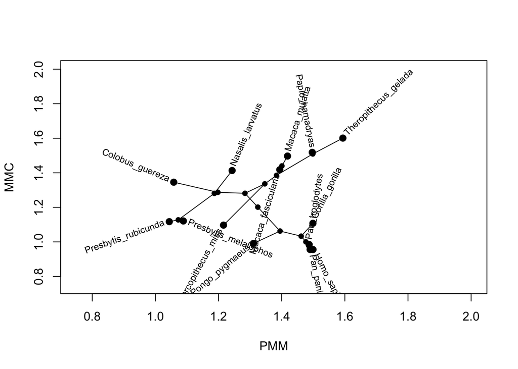

```r
phylomorphospace(phylo,toothdata,xlab="PMM",ylab="MMC",ylim=c(0.75,2.0),xlim=c(0.75,2.0))
```

Finally, we can look at the Disparity Through Time analysis. For this analysis, we’ll also need the mean values for each taxon, so we can use the *tootdata* dataframe (but to run the analyses separately for PMM and MMC we’ll have to create two individual dataframes):

```r
dttMMC<-as.data.frame(toothdata[,c(2,1)])
row.names(dttMMC)<-row.names(toothdata)
names(dttMMC)<-c("MMC","PMM")
dttPMM<-as.data.frame(toothdata[,c(1,2)])
row.names(dttPMM)<-row.names(toothdata)
names(dttPMM)<-c("PMM","MMC")
```

Ok, now we can run the analyses. First, there’s the basic coding from the phytools package:

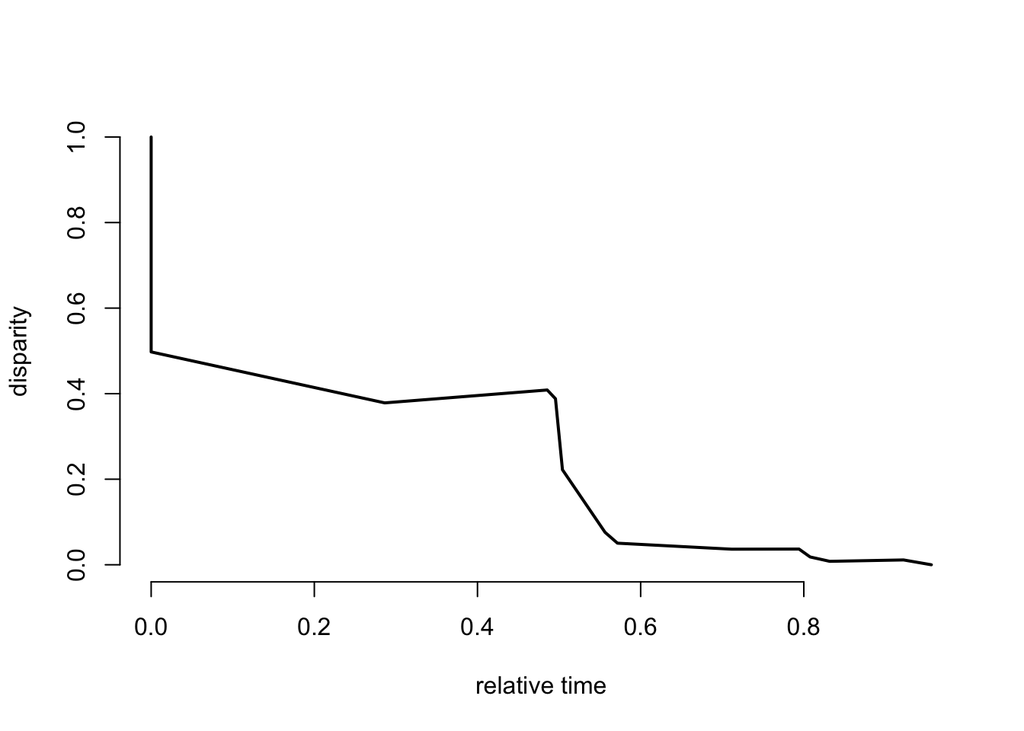

```
## $dtt
##  [1] 1.000000000 0.497598355 0.378438535 0.408621226 0.388138380
##  [6] 0.222117199 0.075781736 0.050508340 0.036438348 0.036728256
## [11] 0.018268846 0.008036655 0.011310585 0.000000000
##
## $times
##                  15        16        21        24        17        22
## 0.0000000 0.0000000 0.2863209 0.4854948 0.4955849 0.5041607 0.5563966
##        18        25        26        19        20        27        23
## 0.5715825 0.7115922 0.7941373 0.8076945 0.8318007 0.9222149 0.9563333
```

```r
dtt(phylo,dttMMC)
```

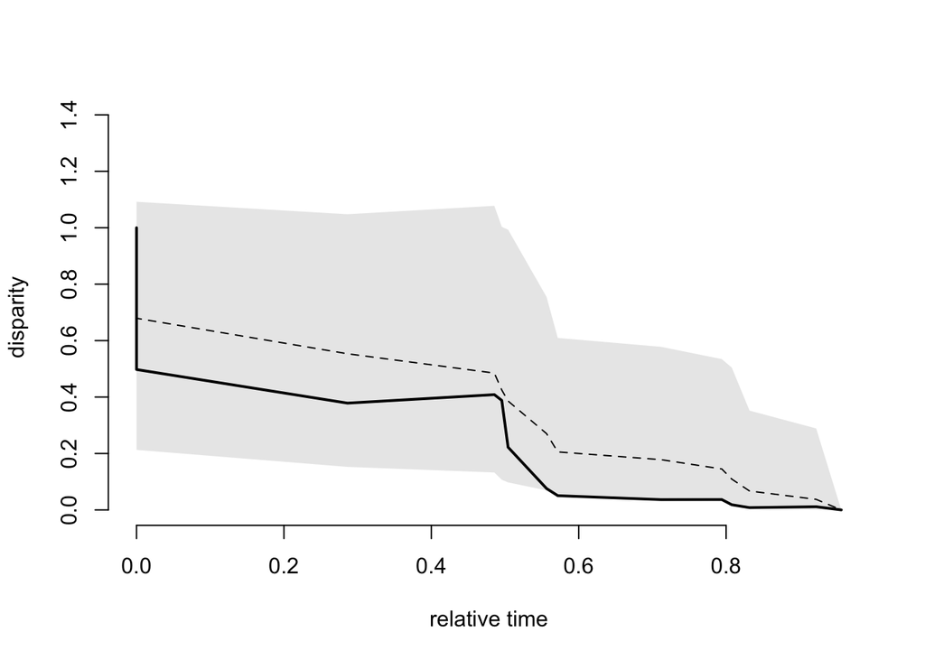

```r
dtt.mmc<-dtt(phylo,dttMMC,nsim=1000,plot=TRUE)
```

```r
dtt.mmc$MDI
```

```
##     avg.sq
## -0.1280675
```

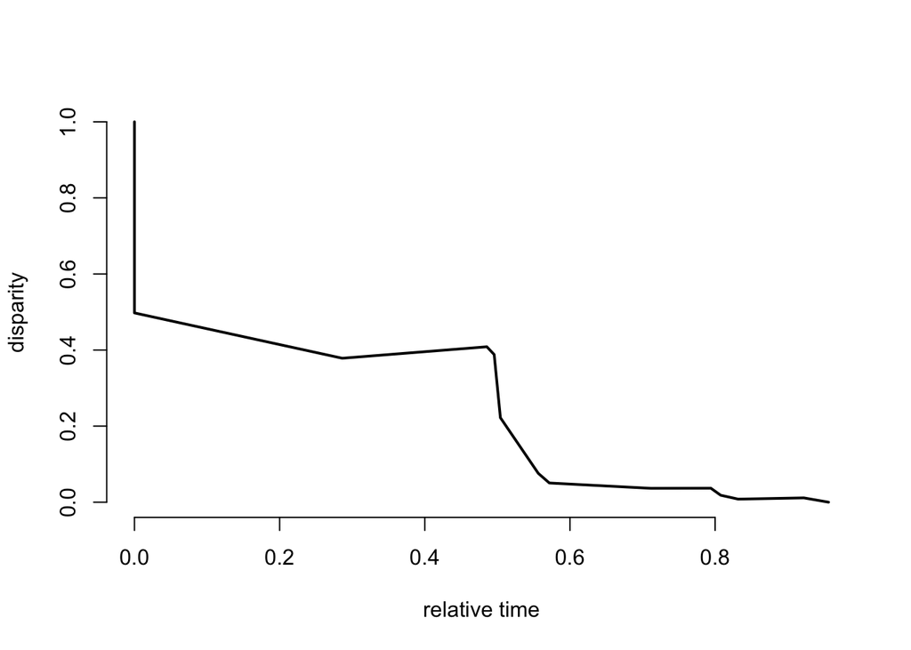

```
## $dtt
##  [1] 1.000000000 0.497598355 0.378438535 0.408621226 0.388138380
##  [6] 0.222117199 0.075781736 0.050508340 0.036438348 0.036728256
## [11] 0.018268846 0.008036655 0.011310585 0.000000000
##
## $times
##                  15        16        21        24        17        22
## 0.0000000 0.0000000 0.2863209 0.4854948 0.4955849 0.5041607 0.5563966
##        18        25        26        19        20        27        23
## 0.5715825 0.7115922 0.7941373 0.8076945 0.8318007 0.9222149 0.9563333
```

```r
dtt(phylo,dttPMM)
```

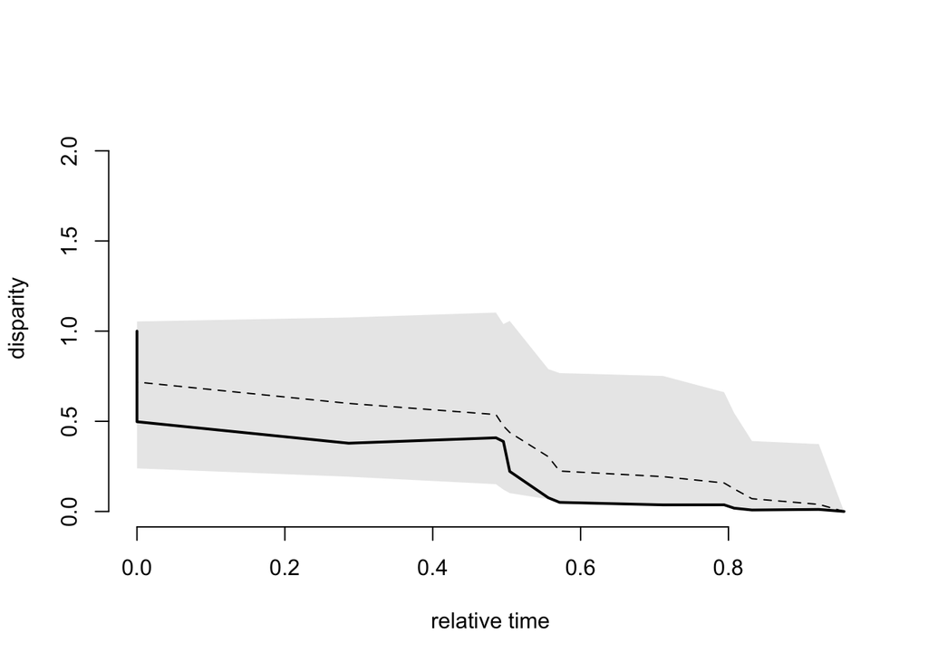

```r
dtt.pmm<-dtt(phylo,dttPMM,nsim=1000,plot=TRUE)
```

```r
dtt.pmm$MDI
```

```
##     avg.sq
## -0.1576555
```

For the paper, however, we used a modified code by Graham Slater that gives a more refined image of the confidence intervals:

```r
dttFullCIs<-function (phy, data, disp = "avg.sq", nsims = 1000, mdi.range = c(0, 1),ciRange=c(0.025,0.975), color = "gray81")
{
    td <- treedata(phy, data, sort = T);
    dtt.data <- dtt(td$phy, td$data, index = disp, plot = F)
   plot(dtt.data$times, dtt.data$dtt, type = "l",col="white",lwd = 2, xlab = "Relative time", ylab = "Disparity")
    s<-vcv(td$phy, td$dat)
    sims <- sim.char(td$phy, s, nsims)
    dtt.sims <- sapply(apply(sims,3, dtt, phy=td$phy, index=disp, plot=F), "[[", "dtt");


    quantiles<-numeric()
for (i in 1:length(dtt.data$times)){

    range<-quantile(dtt.sims[i,],ciRange)
    quantiles<-rbind(quantiles,range)
    }

median.sims <- apply(dtt.sims, 1, median)

x<-rep(dtt.data$times,2)
y<-(quantiles[,1])
y<-append(y,quantiles[,2])
polygon(x,y,border=color,col = color)

lines(dtt.data$times, median.sims, lty = 2,lwd=1.5)
lines(dtt.data$times, dtt.data$dtt,lty= 1,lwd=2.5)

    MDI <- geiger:::.area.between.curves(dtt.data$times, apply(dtt.sims, 1, median),dtt.data$dtt, mdi.range)

 as.data.frame(dtt.sims)->simframe

mdiNull<-numeric(nsims)
for (i in 1:nsims){
    MDIsim <- geiger:::.area.between.curves(dtt.data$times, simframe[,i],dtt.data$dtt, mdi.range)
    mdiNull[i]<-MDIsim
    }

if(MDI<0){
which(mdiNull>0)->pos
(length(pos)/nsims)->prop

}
else {which(mdiNull<0)->pos
(length(pos)/nsims)->prop
}
    return(list(dtt.data = dtt.data, dtt.sims = dtt.sims, times = dtt.data$times, MDI.nullDistribution = mdiNull,
        MDI = MDI,Pvalue=prop))
}
```

Let’s see how this analysis works out:

```r
dttOutmmc<-dttFullCIs(phylo,dttMMC,nsims=1000)
```

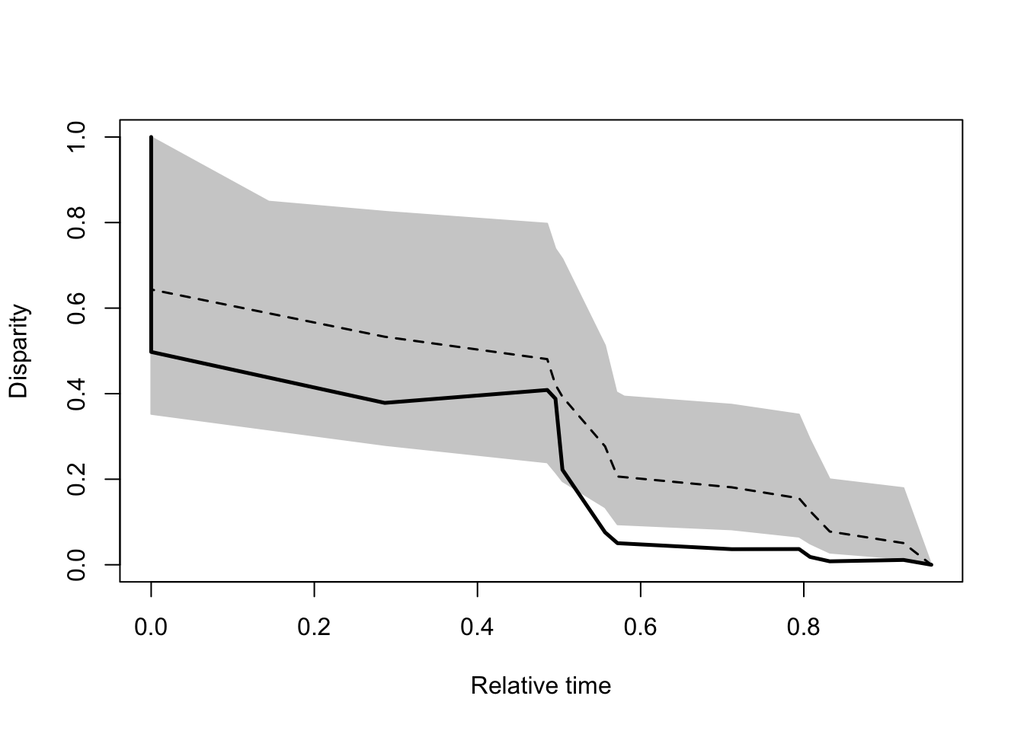

```r
dttOutmmc$MDI
```

```
##         15
## -0.1205755
```

```r
dttOutmmc$Pvalue
```

```
## [1] 0.066
```

```r
dttOutpmm<-dttFullCIs(phylo,dttPMM,nsims=1000)
```

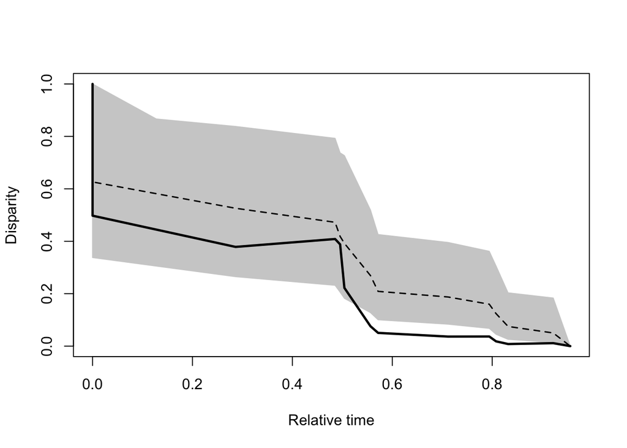

```r
dttOutpmm$MDI
```

```
##         15
## -0.1160961
```

```r
dttOutpmm$Pvalue
```

```
## [1] 0.083
```

As you can see, even with the altered human samples the graphical outputs using the Slater coding look more of less the same.

Ok! That’s all the R code for the mandibular analysis! Again, it looks like there’s been some change in the position of humans with the newer data, which might necessitate us reassessing the status of the fossil taxa… if extant humans are more or less occupying the same range of variation as *Pan*, our interpretation depends on how robust we think the fossil samples are… have anatomically modern humans converged on the *Pan* phenotypes after a long history of wandering from it? Or do we simply have too few fossils to see the full range of variation for those taxa? Something to think about.

If you have any questions regarding this coding, let me know at caschmit [at] bu [dot] edu!